# Avocado price MLR model

Begin by loading in data. Data publically available from [Kaggle](https://www.kaggle.com/neuromusic/avocado-prices).

```r
avocado_raw <- read_csv("data/avocado.csv") %>% janitor::clean_names()
```

```
* `` -> ...1
```

```r
summary(avocado_raw)
```

```
       x1             date            average_price    total_volume          x4046              x4225
 Min.   : 0.00   Min.   :2015-01-04   Min.   :0.440   Min.   :      85   Min.   :       0   Min.   :       0
 1st Qu.:10.00   1st Qu.:2015-10-25   1st Qu.:1.100   1st Qu.:   10839   1st Qu.:     854   1st Qu.:    3009
 Median :24.00   Median :2016-08-14   Median :1.370   Median :  107377   Median :    8645   Median :   29061
 Mean   :24.23   Mean   :2016-08-13   Mean   :1.406   Mean   :  850644   Mean   :  293008   Mean   :  295155
 3rd Qu.:38.00   3rd Qu.:2017-06-04   3rd Qu.:1.660   3rd Qu.:  432962   3rd Qu.:  111020   3rd Qu.:  150207
 Max.   :52.00   Max.   :2018-03-25   Max.   :3.250   Max.   :62505647   Max.   :22743616   Max.   :20470573
     x4770           total_bags         small_bags         large_bags       x_large_bags          type
 Min.   :      0   Min.   :       0   Min.   :       0   Min.   :      0   Min.   :     0.0   Length:18249
 1st Qu.:      0   1st Qu.:    5089   1st Qu.:    2849   1st Qu.:    127   1st Qu.:     0.0   Class :character
 Median :    185   Median :   39744   Median :   26363   Median :   2648   Median :     0.0   Mode  :character
 Mean   :  22840   Mean   :  239639   Mean   :  182195   Mean   :  54338   Mean   :  3106.4
 3rd Qu.:   6243   3rd Qu.:  110783   3rd Qu.:   83338   3rd Qu.:  22029   3rd Qu.:   132.5
 Max.   :2546439   Max.   :19373134   Max.   :13384587   Max.   :5719097   Max.   :551693.7
      year         region
 Min.   :2015   Length:18249
 1st Qu.:2015   Class :character
 Median :2016   Mode  :character
 Mean   :2016
 3rd Qu.:2017
 Max.   :2018
```

### Data preparation

#### Key observations:

- The index column `x1` can go.
- `type` should be a factor.
- `total_bags` is the sum the amount of small, medium, large and extra large bags sold, plus other avocado varieties.
- `total_volume` includes all avocados sold, including 4046 (small hass), 4225 (large hass), 4770 (extra large hass) and also others without a separate volume column (e.g. greenskins), so must be kept.
- `year` should be a factor.
- `region` is categorical and should be a factor. Leads to too many dummy variables and has a `TotalUS` value, worth having two separate data-sets, one with and one without regions..
- Data is gathered weekly, so `Date` does not include daily information, but weekly information.

```r
# Clean df according to observations
avocado <- avocado_raw %>%
  mutate(week = factor(if_else(week(date) %% 4 == 0, 4, week(date) %% 4)),
         month = factor(month(date)),
         year = factor(year),
         type = factor(type),
         region = factor(region)) %>%
  select(average_price, total_volume, x4046, x4225, x4770,total_bags,
         small_bags, large_bags, x_large_bags, type, region, year, month, week) %>%
  rename("small_volume" = "x4046",
         "large_volume" = "x4225",
         "x_large_volume" = "x4770")

avocado_regions <- avocado %>%
  filter(region != "TotalUS")

avocado <- avocado %>%
  filter(region == "TotalUS") %>%
  select(-region)
```

No variables depend linearly on others:

```r
alias(lm(average_price ~ ., avocado_regions))
```

```
Model :
average_price ~ total_volume + small_volume + large_volume +
    x_large_volume + total_bags + small_bags + large_bags + x_large_bags +
    type + region + year + month + week
```

### Exploratory model building

Let us centre on the nationwide data first. Visualise the distribution of the average price:

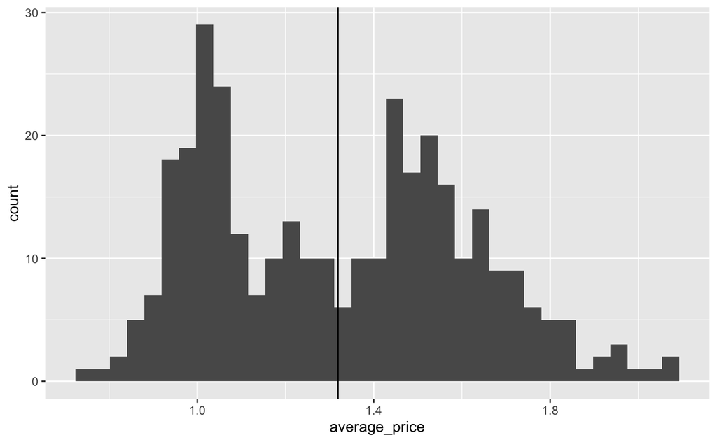

```r
avocado %>%
  # filter(type == "organic") %>%
  ggplot(aes(average_price)) +
  geom_histogram(bins = 35) +
  geom_vline(xintercept = mean(avocado$average_price))
```

Data seems bimodal, with one average for conventional and another one for organic avocados. Quick look at the over-fitted model:

```r
summary(lm(average_price ~ ., avocado))
```

```
Call:
lm(formula = average_price ~ ., data = avocado)

Residuals:
     Min       1Q   Median       3Q      Max
-0.57592 -0.05330  0.00853  0.06949  0.36919

Coefficients:
                 Estimate Std. Error t value Pr(>|t|)
(Intercept)     1.358e+00  6.716e-02  20.221  < 2e-16 ***
total_volume    5.472e-05  2.763e-05   1.981  0.04850 *
small_volume   -5.471e-05  2.762e-05  -1.980  0.04854 *
large_volume   -5.476e-05  2.763e-05  -1.982  0.04834 *
x_large_volume -5.471e-05  2.763e-05  -1.980  0.04858 *
total_bags     -5.489e-01  6.998e-02  -7.843 7.08e-14 ***
small_bags      5.488e-01  6.998e-02   7.843 7.12e-14 ***
large_bags      5.488e-01  6.998e-02   7.843 7.12e-14 ***
x_large_bags    5.488e-01  6.998e-02   7.843 7.12e-14 ***
typeorganic     8.002e-02  5.992e-02   1.336  0.18266
year2016       -5.540e-03  2.042e-02  -0.271  0.78631
year2017        1.448e-01  2.198e-02   6.590 1.88e-10 ***
year2018        1.465e-01  3.660e-02   4.003 7.82e-05 ***
month2         -3.761e-02  2.837e-02  -1.326  0.18592
month3         -2.270e-02  2.797e-02  -0.812  0.41759
month4          2.006e-02  3.095e-02   0.648  0.51742
month5          4.663e-02  3.047e-02   1.530  0.12691
month6          8.836e-02  3.281e-02   2.693  0.00747 **
month7          9.552e-02  3.295e-02   2.898  0.00402 **
month8          1.651e-01  3.104e-02   5.319 2.00e-07 ***
month9          2.694e-01  3.101e-02   8.687  < 2e-16 ***
month10         2.594e-01  3.023e-02   8.581 4.56e-16 ***
month11         1.252e-01  3.120e-02   4.012 7.56e-05 ***
month12        -1.516e-04  3.051e-02  -0.005  0.99604
week2           9.969e-03  1.757e-02   0.567  0.57082
week3          -1.708e-02  1.765e-02  -0.967  0.33406
week4          -1.195e-03  1.768e-02  -0.068  0.94616
---
Signif. codes:  0 ‘***’ 0.001 ‘**’ 0.01 ‘*’ 0.05 ‘.’ 0.1 ‘ ’ 1

Residual standard error: 0.1129 on 311 degrees of freedom
Multiple R-squared:  0.8652,    Adjusted R-squared:  0.8539
F-statistic: 76.77 on 26 and 311 DF,  p-value: < 2.2e-16
```

```r
model_regsubsets <- regsubsets(average_price ~ ., avocado, nvmax = 10)

summary(model_regsubsets)
```

```
Subset selection object
Call: regsubsets.formula(average_price ~ ., avocado, nvmax = 10)
26 Variables  (and intercept)
               Forced in Forced out
total_volume       FALSE      FALSE
small_volume       FALSE      FALSE
large_volume       FALSE      FALSE
x_large_volume     FALSE      FALSE
total_bags         FALSE      FALSE
small_bags         FALSE      FALSE
large_bags         FALSE      FALSE
x_large_bags       FALSE      FALSE
typeorganic        FALSE      FALSE
year2016           FALSE      FALSE
year2017           FALSE      FALSE
year2018           FALSE      FALSE
month2             FALSE      FALSE
month3             FALSE      FALSE
month4             FALSE      FALSE
month5             FALSE      FALSE
month6             FALSE      FALSE
month7             FALSE      FALSE
month8             FALSE      FALSE
month9             FALSE      FALSE
month10            FALSE      FALSE
month11            FALSE      FALSE
month12            FALSE      FALSE
week2              FALSE      FALSE
week3              FALSE      FALSE
week4              FALSE      FALSE
1 subsets of each size up to 10
Selection Algorithm: exhaustive
          total_volume small_volume large_volume x_large_volume total_bags small_bags large_bags x_large_bags
1  ( 1 )  " "          " "          "*"          " "            " "        " "        " "        " "
2  ( 1 )  " "          " "          "*"          " "            " "        " "        " "        " "
3  ( 1 )  " "          " "          "*"          " "            " "        " "        " "        " "
4  ( 1 )  " "          " "          "*"          " "            " "        " "        " "        " "
5  ( 1 )  " "          " "          "*"          " "            " "        " "        " "        " "
6  ( 1 )  " "          " "          "*"          " "            " "        " "        " "        " "
7  ( 1 )  " "          " "          "*"          " "            " "        " "        " "        " "
```

[output cut: 10 more lines]

```
7  ( 1 )  " "         " "      "*"      "*"      " "    " "    " "    " "    " "    " "    "*"    "*"    "*"
8  ( 1 )  " "         " "      "*"      " "      " "    " "    " "    " "    " "    " "    " "    "*"    "*"
9  ( 1 )  " "         " "      "*"      "*"      " "    " "    " "    " "    " "    " "    " "    "*"    "*"
10  ( 1 ) " "         " "      "*"      "*"      " "    " "    " "    " "    " "    " "    "*"    "*"    "*"
          month11 month12 week2 week3 week4
1  ( 1 )  " "     " "     " "   " "   " "
2  ( 1 )  " "     " "     " "   " "   " "
3  ( 1 )  " "     " "     " "   " "   " "
4  ( 1 )  " "     " "     " "   " "   " "
5  ( 1 )  " "     " "     " "   " "   " "
6  ( 1 )  " "     " "     " "   " "   " "
7  ( 1 )  "*"     " "     " "   " "   " "
8  ( 1 )  " "     " "     " "   " "   " "
9  ( 1 )  " "     " "     " "   " "   " "
10  ( 1 ) " "     " "     " "   " "   " "
```

Key predictors nationwide seem to be the volume of large hass avocados sold, the year and the month. When using nationwide data, there likely are not enough observations to split the sample into train and test sets. Instead, in order to compare models, indicators that penalise over-fitting should be preferred. These indicators are adjusted $R^2$ and BIC.

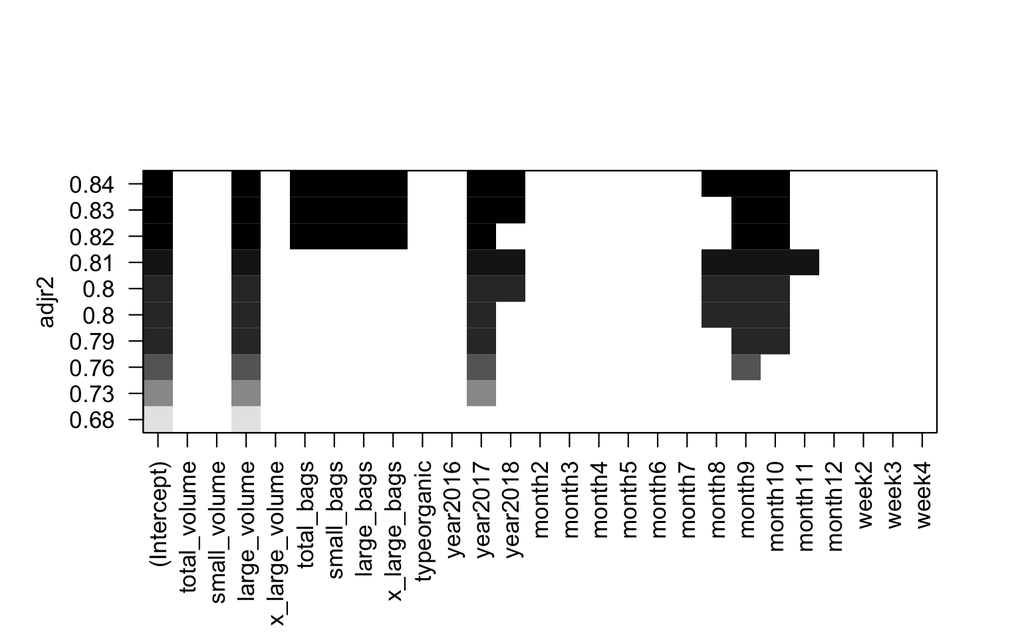

```r
plot(model_regsubsets, scale = "adjr2")
```

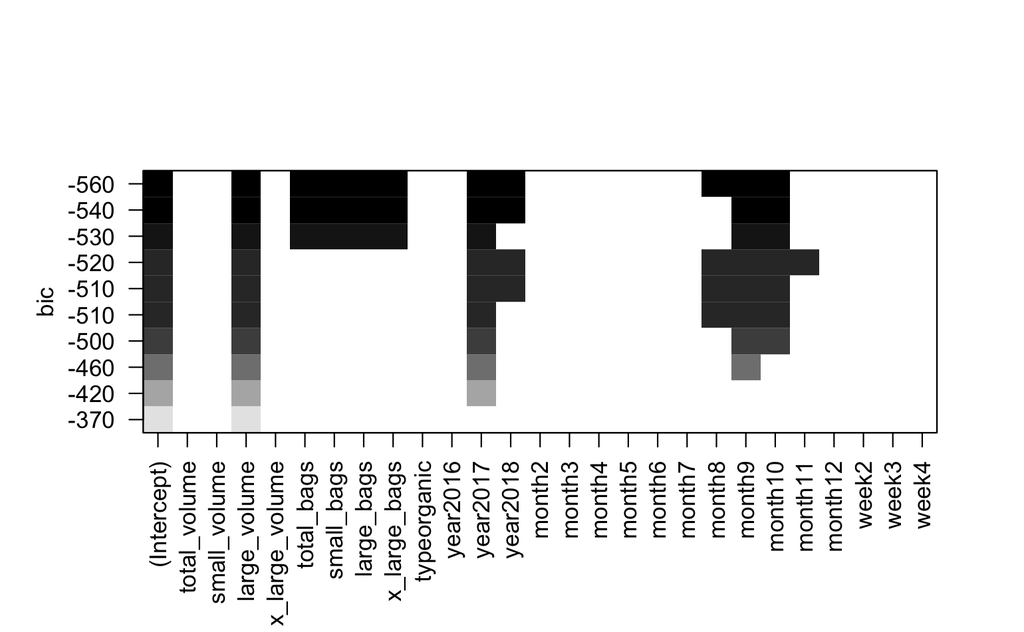

```r
plot(model_regsubsets, scale = "bic")
```

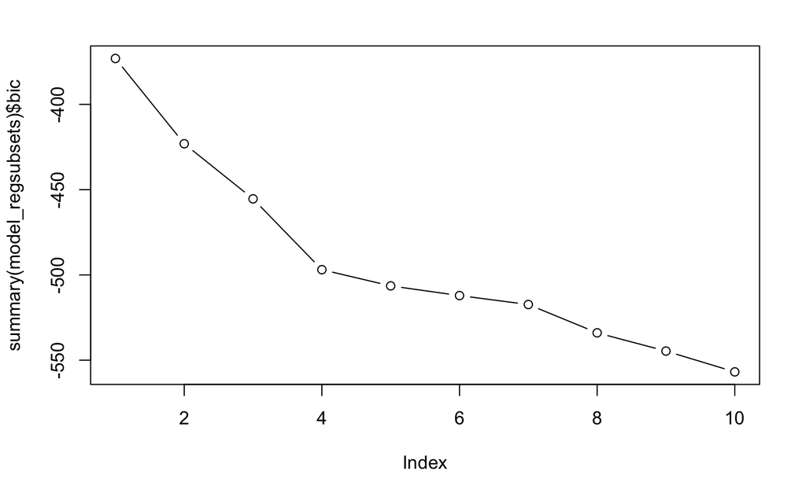

```r
plot(summary(model_regsubsets)$bic, type = "b")
```

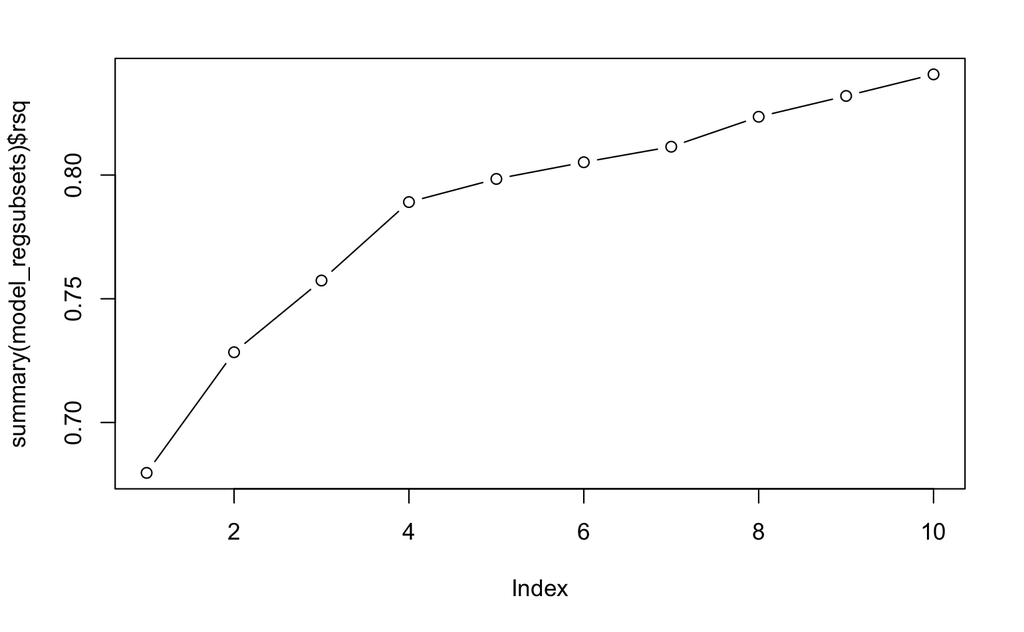

```r
plot(summary(model_regsubsets)$rsq, type = "b")
```

These two plots show that, in terms of model fitness, a model of more than 4 variables has diminishing returns, with perhaps another turning point after more than 7. Optimally, we would want our model to have either 4 or 8 variables to avoid diminishing returns in the parsimony vs. explanatory power trade-off.

Note that not all categories in `year` and `month` seem statistically significant. Let us compare how the models with and without them do via analysis of variance:

```r
anova(lm(average_price ~ large_volume + month, avocado), lm(average_price ~ large_volume, avocado))
```

```
Analysis of Variance Table

Model 1: average_price ~ large_volume + month
Model 2: average_price ~ large_volume
  Res.Df    RSS  Df Sum of Sq      F    Pr(>F)
1    325 6.8144
2    336 9.4251 -11   -2.6107 11.319 < 2.2e-16 ***
---
Signif. codes:  0 ‘***’ 0.001 ‘**’ 0.01 ‘*’ 0.05 ‘.’ 0.1 ‘ ’ 1
```

```r
anova(lm(average_price ~ large_volume + year + month, avocado), lm(average_price ~ large_volume + year, avocado))
```

```
Analysis of Variance Table

Model 1: average_price ~ large_volume + year + month
Model 2: average_price ~ large_volume + year
  Res.Df    RSS  Df Sum of Sq      F    Pr(>F)
1    322 5.0851
2    333 7.9312 -11    -2.846 16.383 < 2.2e-16 ***
---
Signif. codes:  0 ‘***’ 0.001 ‘**’ 0.01 ‘*’ 0.05 ‘.’ 0.1 ‘ ’ 1
```

It seems that both categories are statistically significant.

```r
explanatory_model <- lm(average_price ~ large_volume + year + month, avocado)

summary(explanatory_model)
```

```
Call:
lm(formula = average_price ~ large_volume + year + month, data = avocado)

Residuals:
     Min       1Q   Median       3Q      Max
-0.56972 -0.05890  0.01071  0.07441  0.37582

Coefficients:
               Estimate Std. Error t value Pr(>|t|)
(Intercept)   1.423e+00  2.577e-02  55.208  < 2e-16 ***
large_volume -3.965e-08  1.169e-09 -33.913  < 2e-16 ***
year2016     -8.833e-03  1.747e-02  -0.506 0.613406
year2017      1.440e-01  1.743e-02   8.260 3.84e-15 ***
year2018      1.470e-01  3.103e-02   4.735 3.28e-06 ***
month2       -2.469e-02  3.055e-02  -0.808 0.419538
month3       -1.434e-02  3.009e-02  -0.476 0.634070
month4        2.616e-02  3.301e-02   0.792 0.428791
month5        6.298e-02  3.235e-02   1.947 0.052427 .
month6        1.113e-01  3.376e-02   3.296 0.001088 **
month7        8.642e-02  3.234e-02   2.672 0.007922 **
month8        1.573e-01  3.304e-02   4.761 2.91e-06 ***
month9        2.723e-01  3.378e-02   8.059 1.51e-14 ***
month10       2.512e-01  3.239e-02   7.755 1.17e-13 ***
month11       1.200e-01  3.310e-02   3.626 0.000334 ***
month12      -3.919e-03  3.303e-02  -0.119 0.905650
---
Signif. codes:  0 ‘***’ 0.001 ‘**’ 0.01 ‘*’ 0.05 ‘.’ 0.1 ‘ ’ 1

Residual standard error: 0.1257 on 322 degrees of freedom
Multiple R-squared:  0.8271,    Adjusted R-squared:  0.8191
F-statistic: 102.7 on 15 and 322 DF,  p-value: < 2.2e-16
```

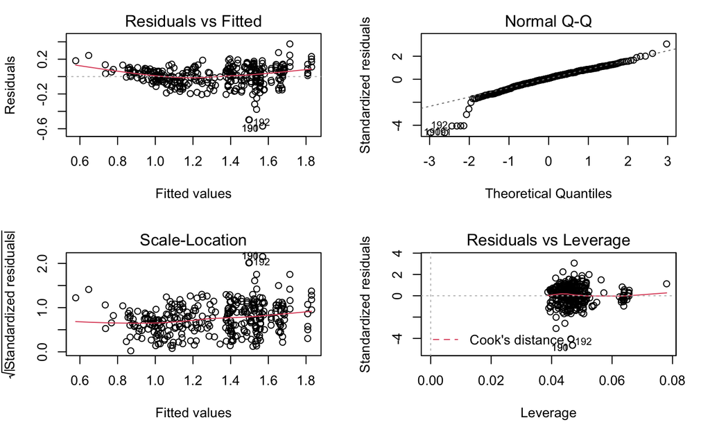

```r
par(mfrow = c(2, 2))
plot(explanatory_model)
```

Assuming that what models nationwide data will model the data grouped by region, let us now build the model with the inclusion of regional data.

```r
anova(lm(average_price ~ large_volume + year + month, avocado_regions), lm(average_price ~ large_volume + year + month + region, avocado_regions))
```

```
Analysis of Variance Table

Model 1: average_price ~ large_volume + year + month
Model 2: average_price ~ large_volume + year + month + region
  Res.Df    RSS Df Sum of Sq      F    Pr(>F)
1  17895 2459.8
2  17843 1800.9 52     658.9 125.55 < 2.2e-16 ***
---
Signif. codes:  0 ‘***’ 0.001 ‘**’ 0.01 ‘*’ 0.05 ‘.’ 0.1 ‘ ’ 1
```

It seems that regional factors are statistically significant.

```r
model_regsubsets <- regsubsets(average_price ~ ., select(avocado_regions, -region), nvmax = 10)

summary(model_regsubsets)
```

```
Subset selection object
Call: regsubsets.formula(average_price ~ ., select(avocado_regions,
    -region), nvmax = 10)
26 Variables  (and intercept)
               Forced in Forced out
total_volume       FALSE      FALSE
small_volume       FALSE      FALSE
large_volume       FALSE      FALSE
x_large_volume     FALSE      FALSE
total_bags         FALSE      FALSE
small_bags         FALSE      FALSE
large_bags         FALSE      FALSE
x_large_bags       FALSE      FALSE
typeorganic        FALSE      FALSE
year2016           FALSE      FALSE
year2017           FALSE      FALSE
year2018           FALSE      FALSE
month2             FALSE      FALSE
month3             FALSE      FALSE
month4             FALSE      FALSE
month5             FALSE      FALSE
month6             FALSE      FALSE
month7             FALSE      FALSE
month8             FALSE      FALSE
month9             FALSE      FALSE
month10            FALSE      FALSE
month11            FALSE      FALSE
month12            FALSE      FALSE
week2              FALSE      FALSE
week3              FALSE      FALSE
week4              FALSE      FALSE
1 subsets of each size up to 10
Selection Algorithm: exhaustive
          total_volume small_volume large_volume x_large_volume total_bags small_bags large_bags x_large_bags
1  ( 1 )  " "          " "          " "          " "            " "        " "        " "        " "
2  ( 1 )  " "          " "          " "          " "            " "        " "        " "        " "
3  ( 1 )  " "          "*"          " "          " "            " "        " "        " "        " "
4  ( 1 )  " "          "*"          " "          " "            " "        " "        " "        " "
5  ( 1 )  " "          "*"          " "          " "            " "        " "        " "        " "
6  ( 1 )  " "          "*"          " "          " "            " "        " "        " "        " "
```

[output cut: 11 more lines]

```
7  ( 1 )  "*"         " "      "*"      " "      " "    " "    " "    " "    " "    "*"    "*"    "*"    "*"
8  ( 1 )  "*"         " "      "*"      " "      " "    " "    " "    " "    " "    "*"    "*"    "*"    "*"
9  ( 1 )  "*"         " "      "*"      " "      " "    " "    " "    " "    " "    "*"    "*"    "*"    "*"
10  ( 1 ) "*"         "*"      "*"      " "      " "    " "    " "    " "    " "    "*"    "*"    "*"    "*"
          month11 month12 week2 week3 week4
1  ( 1 )  " "     " "     " "   " "   " "
2  ( 1 )  " "     " "     " "   " "   " "
3  ( 1 )  " "     " "     " "   " "   " "
4  ( 1 )  " "     " "     " "   " "   " "
5  ( 1 )  " "     " "     " "   " "   " "
6  ( 1 )  " "     " "     " "   " "   " "
7  ( 1 )  " "     " "     " "   " "   " "
8  ( 1 )  "*"     " "     " "   " "   " "
9  ( 1 )  "*"     " "     " "   " "   " "
10  ( 1 ) "*"     " "     " "   " "   " "
```

It also seems that for the regional data, the model cannot be the same as for the nationwide data. Given that the value `TotalUS` in the `region` column seems misleading, let us go back to data preparation and nation-wide model building.

### New model using `caret`.

#### Data preparation

```r
# Clean df according to observations, getting rid of "TotalUS" rows and "region" column
avocado <- avocado_raw %>%
  mutate(week = factor(if_else(week(date) %% 4 == 0, 4, week(date) %% 4)),
         month = factor(month(date)),
         year = factor(year),
         type = factor(type),
         region = factor(region)) %>%
  select(average_price, total_volume, x4046, x4225, x4770,total_bags,
         small_bags, large_bags, x_large_bags, type, region, year, month, week) %>%
  rename("small_volume" = "x4046",
         "large_volume" = "x4225",
         "x_large_volume" = "x4770") %>%
  filter(region != "TotalUS") %>%
  select(-region)
```

```r
library(caret)
```

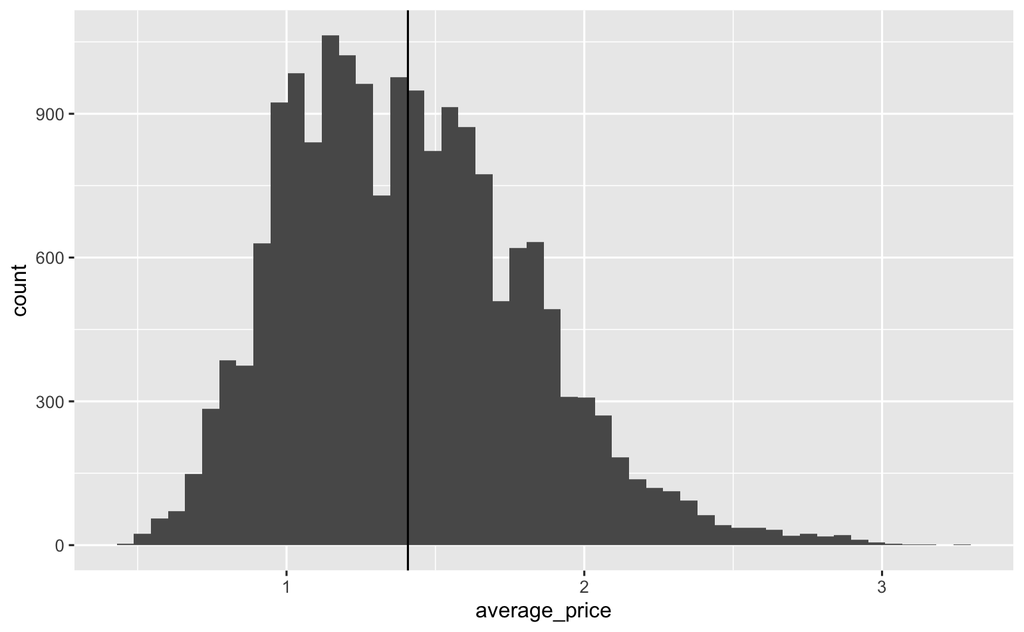

```r
avocado %>%
  ggplot(aes(average_price)) +
  geom_histogram(bins = 50) +
  geom_vline(xintercept = mean(avocado$average_price))
```

Create test and train sets

```r
train_index <- createDataPartition(avocado$average_price, p = 0.8, list = FALSE, times = 1)

train <- avocado[train_index, ]
test <- avocado[-train_index, ]
```

Create model

```r
model_regsubsets <- regsubsets(average_price ~ ., train, nvmax = 10)

summary(model_regsubsets)
```

```
Subset selection object
Call: regsubsets.formula(average_price ~ ., train, nvmax = 10)
26 Variables  (and intercept)
               Forced in Forced out
total_volume       FALSE      FALSE
small_volume       FALSE      FALSE
large_volume       FALSE      FALSE
x_large_volume     FALSE      FALSE
total_bags         FALSE      FALSE
small_bags         FALSE      FALSE
large_bags         FALSE      FALSE
x_large_bags       FALSE      FALSE
typeorganic        FALSE      FALSE
year2016           FALSE      FALSE
year2017           FALSE      FALSE
year2018           FALSE      FALSE
month2             FALSE      FALSE
month3             FALSE      FALSE
month4             FALSE      FALSE
month5             FALSE      FALSE
month6             FALSE      FALSE
month7             FALSE      FALSE
month8             FALSE      FALSE
month9             FALSE      FALSE
month10            FALSE      FALSE
month11            FALSE      FALSE
month12            FALSE      FALSE
week2              FALSE      FALSE
week3              FALSE      FALSE
week4              FALSE      FALSE
1 subsets of each size up to 10
Selection Algorithm: exhaustive
          total_volume small_volume large_volume x_large_volume total_bags small_bags large_bags x_large_bags
1  ( 1 )  " "          " "          " "          " "            " "        " "        " "        " "
2  ( 1 )  " "          " "          " "          " "            " "        " "        " "        " "
3  ( 1 )  " "          "*"          " "          " "            " "        " "        " "        " "
4  ( 1 )  " "          "*"          " "          " "            " "        " "        " "        " "
5  ( 1 )  " "          "*"          " "          " "            " "        " "        " "        " "
6  ( 1 )  " "          "*"          " "          " "            " "        " "        " "        " "
7  ( 1 )  " "          "*"          " "          " "            " "        " "        " "        " "
```

[output cut: 10 more lines]

```
7  ( 1 )  "*"         " "      "*"      " "      " "    " "    " "    " "    " "    "*"    "*"    "*"    "*"
8  ( 1 )  "*"         " "      "*"      " "      " "    " "    " "    " "    " "    "*"    "*"    "*"    "*"
9  ( 1 )  "*"         " "      "*"      " "      " "    " "    " "    " "    " "    "*"    "*"    "*"    "*"
10  ( 1 ) "*"         " "      "*"      " "      " "    " "    " "    " "    "*"    "*"    "*"    "*"    "*"
          month11 month12 week2 week3 week4
1  ( 1 )  " "     " "     " "   " "   " "
2  ( 1 )  " "     " "     " "   " "   " "
3  ( 1 )  " "     " "     " "   " "   " "
4  ( 1 )  " "     " "     " "   " "   " "
5  ( 1 )  " "     " "     " "   " "   " "
6  ( 1 )  " "     " "     " "   " "   " "
7  ( 1 )  " "     " "     " "   " "   " "
8  ( 1 )  "*"     " "     " "   " "   " "
9  ( 1 )  "*"     " "     " "   " "   " "
10  ( 1 ) "*"     " "     " "   " "   " "
```

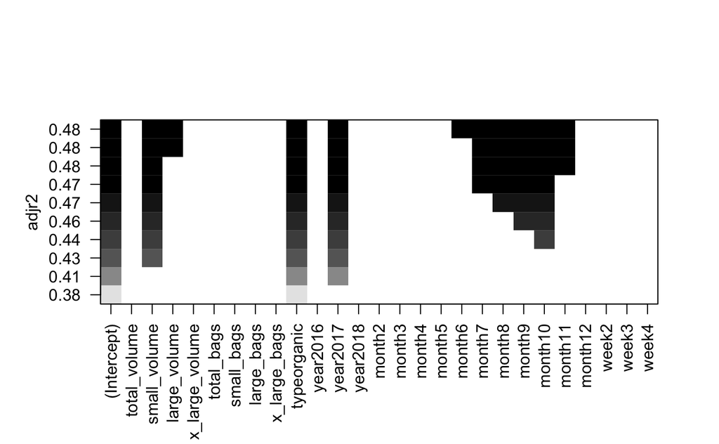

```r
plot(model_regsubsets, scale = "adjr2")
```

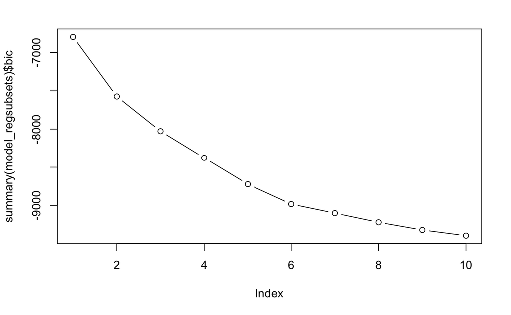

```r
plot(summary(model_regsubsets)$bic, type = "b")
```

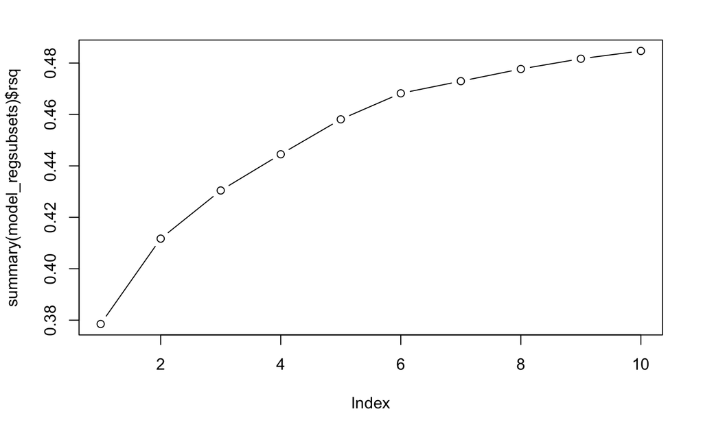

```r
plot(summary(model_regsubsets)$rsq, type = "b")
```

There seems to be no significant turning point. Thus, comparing the BIC and adjusted $R^2$ criteria, let us conclude that the explanatory model:

```r
explanatory_model <- lm(average_price ~ type + small_volume + year + month, train)

summary(explanatory_model)
```

```
Call:
lm(formula = average_price ~ type + small_volume + year + month,
    data = train)

Residuals:
     Min       1Q   Median       3Q      Max
-1.23330 -0.18455 -0.00814  0.17349  1.50407

Coefficients:
               Estimate Std. Error t value Pr(>|t|)
(Intercept)   1.058e+00  9.092e-03 116.322  < 2e-16 ***
typeorganic   4.568e-01  5.148e-03  88.733  < 2e-16 ***
small_volume -1.091e-07  4.947e-09 -22.049  < 2e-16 ***
year2016     -4.038e-02  6.170e-03  -6.545 6.13e-11 ***
year2017      1.383e-01  6.154e-03  22.480  < 2e-16 ***
year2018      9.226e-02  1.099e-02   8.393  < 2e-16 ***
month2       -2.836e-02  1.074e-02  -2.639  0.00831 **
month3        2.054e-02  1.058e-02   1.942  0.05218 .
month4        7.336e-02  1.162e-02   6.316 2.77e-10 ***
month5        6.143e-02  1.133e-02   5.420 6.07e-08 ***
month6        1.248e-01  1.189e-02  10.495  < 2e-16 ***
month7        1.619e-01  1.136e-02  14.247  < 2e-16 ***
month8        2.235e-01  1.169e-02  19.118  < 2e-16 ***
month9        2.677e-01  1.190e-02  22.498  < 2e-16 ***
month10       2.721e-01  1.135e-02  23.967  < 2e-16 ***
month11       1.522e-01  1.165e-02  13.066  < 2e-16 ***
month12       2.471e-02  1.169e-02   2.113  0.03460 *
---
Signif. codes:  0 ‘***’ 0.001 ‘**’ 0.01 ‘*’ 0.05 ‘.’ 0.1 ‘ ’ 1

Residual standard error: 0.2888 on 14313 degrees of freedom
Multiple R-squared:  0.4883,    Adjusted R-squared:  0.4878
F-statistic: 853.8 on 16 and 14313 DF,  p-value: < 2.2e-16
```

Test this model:

```r
predictions_test <- test %>%
  modelr::add_predictions(explanatory_model) %>%
  select(average_price, pred)
```

The mean squared error:

```r
mean((predictions_test$pred - test$average_price)**2)
```

```
[1] 0.08503963
```

Double check the value for the train set:

```r
predictions_train <- train %>%
  modelr::add_predictions(explanatory_model) %>%
  select(average_price, pred)
```

```r
mean((predictions_train$pred - train$average_price)**2)
```

```
[1] 0.08331272
```

Error is lower on the train set, indicating that the model is well-fit.